# Practical_Machine_Learning_Project

Md Ahmed

August 9th, 2017

## Project Report: Machine Learning Algorithms

We are given two sets of data collected from accelerometers placed on the belt, forearm, arm, and dumbell of 6 research study participants for this machine learning project. Training data stems from accelerometers with label identifying the quality of the activity the participant was doing. Testing data also comprised of accelerometer data without identifiable label(A-E).

The definitive instruction for this project is to use data to predict whether the exercise is being done properly or improperly based solely on accelerometer data measurements. The participants were instructed to perform the exercise either properly (Class A) or in a way which replicated 4 common weightlifting mistakes (Classes B, C, D, and E).

**The question is, would we be able to predict appropriately each participants exercise manner by processing data gathered from classe(A-E) accelerometers? In that persuasion, we should apply some Machine Learning(ML) algorithms on ‘trainData’ and test them on given ‘test dataset’ for ‘classe-level’ based exercise manner prediction.**

### 1. Project write up Sequence:

Here in drop down, I wrote the needed ‘code’ along with ‘line-description’ on each step of the process of ML-algorithms. I have used four machine learnig algorithms are Classification Tree, lda, gbm and random forest. I also used cross-validation with ‘method’ and ‘k-folds’ with number within all model. At the end of each ML-algorithm run, I presented the quantified ‘accuracy rate’.

These findings would help us to analyse and predict the manner, in which participants did their exercise regime.

### 2. Data loading, visual overview and manipulation:

```r
# Necessary library loaded
library(easypackages)
```

```r
suppressMessages(libraries("formattable", "dplyr", "tidyr", "ggplot2"))
# loading and reading data file from my desktop
trainDataSet <- read.csv("pml-training.csv", na.strings = c("", "NA"), header = TRUE)
testDataSet  <- read.csv("pml-testing.csv",  na.strings = c("", "NA"), header = TRUE)

# data dimension with row and columns
rbind ( trainDataSet = dim(trainDataSet), testDataSet = dim(testDataSet) )
```

```
##               [,1] [,2]
## trainDataSet 19622  160
## testDataSet     20  160
```

### 2.a. Row-Columnar percentile presentation of classe(A-E) variables by each user

This columnar overview rendered in a 100% scale, which displays, how each user did their exercise regime(A-E), in what percentage of the total workout sequence.

```r
# percentile projection of classe elements by user name
trainDataSet %>% count(classe, user_name) %>% group_by(user_name) %>% mutate(n=percent(n/sum(n),0))%>% spread(classe, n) %>% formattable(align = 'l')
```

| user_name | A | B | C | D | E |
| --- | --- | --- | --- | --- | --- |
| adelmo | 30% | 20% | 19% | 13% | 18% |
| carlitos | 27% | 22% | 16% | 16% | 20% |
| charles | 25% | 21% | 15% | 18% | 20% |
| eurico | 28% | 19% | 16% | 19% | 18% |
| jeremy | 35% | 14% | 19% | 15% | 17% |
| pedro | 25% | 19% | 19% | 18% | 19% |

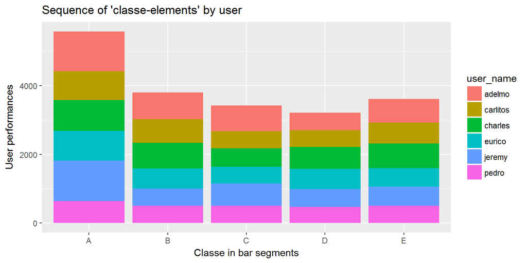

```r
ggplot(trainDataSet, aes(x=classe, fill=user_name)) + geom_bar() + xlab("Classe in bar segments") + ylab("User performances") + ggtitle("Sequence of 'classe-elements' by user")
```

### 3. DataSet Partition and Exploratory data Cleaning:

```r
suppressMessages(library(caret))
# Create Data Partition with 0.75 is training and 0.25 test dataset
inTrain <- createDataPartition(trainDataSet$classe, p=0.75, list=FALSE)
TrainSet <- trainDataSet[inTrain, ]
TestSet  <- trainDataSet[-inTrain,]

# quick data-dimension after data partition
rbind ( TrainSet = dim(TrainSet), TestSet = dim(TestSet) )
```

```
##           [,1] [,2]
## TrainSet 14718  160
## TestSet   4904  160
```

```
#> **Note: some machine learning algoriths do not accept 'NA' values inside the DataSet.So we will do some 'NA' input manipulation.
```

```r
# checking number of columns have 'NA' values with percentile projeciton in a table
table (NA_Value_Percent <- round(colMeans(is.na(TrainSet)), 2))
```

```
##
##    0 0.98
##   60  100
```

**Note:** We see that 100-variables have more than 98 percent data with “NA” input ‘filled-in’ and only 60-variables have complete data set. Variables with 98% data is ‘NA’ doesn’t make any quantifiable effect in decision making anlytic processes.

```r
# so we'd eliminate all variable-columns, where more than 96% of the input are 'NA'
All_NA_columns <- sapply(TrainSet, function(x) mean(is.na(x))) > 0.96

# removing columns with 96% 'NA' only input from both 'Train and Test' dataset
TrainSet <- TrainSet[, All_NA_columns == FALSE]
TestSet  <- TestSet [, All_NA_columns == FALSE]

# a quick view of how many 'variable-columns' left after 'NA-elimination' process
rbind(TrainSet = dim(TrainSet), TestSet = dim(TestSet))
```

```
##           [,1] [,2]
## TrainSet 14718   60
## TestSet   4904   60
```